# Differentially expressed protein analysis of SWATH data using the LIMMA package

This worflow shows how to process data from SWATH-MS protein quantification, in order to study differential expression of the proteins between the different conditions.

The data in this example come from : Bjelosevic S, Pascovici D, Ping H, et.al. Quantitative age-specific variability of plasma proteins in healthy neonates, children and adults. Molecular & Cellular Proteomics (March 23 2017). Four conditions are compared each conditions have ten replicates :  
-neonates  
-child less than one year old  
-child between 1 and five years old  
-adults

146 proteins were identified and quantified.

Here we gonna use the limma package to perform the normalization of the data and the differential expression annalysis. Limma is a Bioconductor package which uses linear model for analysing experiments and the assessment of differential expression.

# 1. loading and visualizing the data

```r
data<-read.table("SWATH.example.data.csv", sep=",",header=T, row.names = 1)
data
```

|  | Sample.1 | Sample.2 | Sample.3 | Sample.4 | Sample.5 | Sample.6 | Sample.7 | Sample.8 | Sample.9 | Sample.10 | Sample.11 | Sample.12 | Sample.13 | Sample.14 | Sample.15 | Sample.16 | Sample.17 | Sample.18 | Sample.19 | Sample.20 | Sample.21 | Sample.22 | Sample.23 | Sample.24 | Sample.25 | Sample.26 | Sample.27 | Sample.28 | Sample.29 | … |
| --- | --- | --- | --- | --- | --- | --- | --- | --- | --- | --- | --- | --- | --- | --- | --- | --- | --- | --- | --- | --- | --- | --- | --- | --- | --- | --- | --- | --- | --- | --- |
| sp\|A0M8Q6\|LAC7_HUMAN | 1.115502e+05 | 9.203458e+03 | 6.672549e+04 | 5.991088e+04 | 1.642215e+05 | 9.143973e+03 | 6.409901e+06 | 1.238785e+04 | 7.809981e+03 | 4.553976e+04 | 5.593150e+04 | 3.501655e+04 | 3.254635e+04 | 5.664431e+04 | 1.839196e+04 | 3.113175e+06 | 1.320937e+04 | 1.982661e+04 | 4.225821e+06 | 1.682750e+05 | 2.277252e+06 | 6.397863e+06 | 3.189287e+06 | 3.628608e+06 | 4.121755e+06 | 1.426761e+05 | 4.140672e+06 | 1.802475e+05 | 5.826897e+06 | … |
| sp\|B9A064\|IGLL5_HUMAN | 6.555987e+06 | 7.765069e+06 | 9.187741e+06 | 7.691362e+06 | 1.498776e+07 | 1.374116e+07 | 8.230958e+06 | 8.681886e+06 | 9.058707e+06 | 8.188822e+06 | 2.531991e+06 | 3.934526e+06 | 1.700102e+06 | 4.418838e+06 | 5.584636e+06 | 3.334236e+06 | 3.871055e+06 | 3.312348e+06 | 4.053520e+06 | 4.567918e+06 | 9.331017e+06 | 1.055792e+07 | 6.857038e+06 | 8.977858e+06 | 9.036241e+06 | 1.460044e+07 | 1.090076e+07 | 1.178051e+07 | 9.930735e+06 | … |
| sp\|O14791\|APOL1_HUMAN | 1.001121e+07 | 6.967989e+06 | 8.196725e+06 | 7.793772e+06 | 4.469132e+06 | 2.344268e+05 | 1.072176e+07 | 2.178108e+05 | 1.626200e+05 | 2.884709e+05 | 8.933724e+06 | 8.123464e+05 | 8.198270e+05 | 4.858403e+05 | 6.382900e+05 | 5.737175e+06 | 7.894232e+06 | 7.794366e+06 | 3.373264e+05 | 8.217965e+05 | 1.036517e+06 | 8.268936e+05 | 8.869152e+05 | 1.007503e+06 | 9.127178e+05 | 1.089386e+06 | 7.271341e+05 | 1.024629e+06 | 5.359292e+05 | … |
| sp\|O43866\|CD5L_HUMAN | 8.159506e+04 | 6.204646e+05 | 1.567635e+05 | 2.038546e+05 | 1.109301e+05 | 2.877470e+05 | 6.997967e+04 | 2.019811e+05 | 1.118168e+05 | 1.388014e+05 | 1.591100e+06 | 8.304909e+05 | 1.683988e+06 | 8.369937e+05 | 1.024494e+06 | 1.487672e+06 | 8.896914e+05 | 6.911559e+05 | 7.834091e+05 | 1.137166e+06 | 1.474772e+06 | 3.229527e+06 | 5.422559e+05 | 7.143334e+05 | 1.521902e+06 | 9.076956e+05 | 9.373061e+05 | 1.809989e+06 | 1.370390e+06 | … |
| sp\|O75636\|FCN3_HUMAN | 2.559217e+05 | 3.979038e+05 | 3.513910e+05 | 3.117654e+05 | 3.523802e+05 | 4.164043e+05 | 1.661627e+05 | 1.592014e+05 | 3.600346e+05 | 4.019163e+05 | 6.269995e+05 | 4.309955e+05 | 5.264501e+05 | 3.827408e+05 | 4.612140e+05 | 4.070175e+05 | 4.470716e+05 | 4.385885e+05 | 2.046635e+05 | 3.899665e+05 | 3.983688e+05 | 4.408848e+05 | 3.895040e+05 | 4.880614e+05 | 3.715512e+05 | 2.801026e+05 | 4.840683e+05 | 4.352776e+05 | 3.844813e+05 | … |
| sp\|O75882\|ATRN_HUMAN | 1.767532e+05 | 1.558307e+05 | 1.316840e+05 | 1.857808e+05 | 2.112565e+05 | 2.224510e+05 | 1.410986e+05 | 1.870620e+05 | 1.454212e+05 | 1.771302e+05 | 2.103269e+05 | 1.597351e+05 | 1.954820e+05 | 1.480458e+05 | 2.178803e+05 | 2.424497e+05 | 1.444728e+05 | 2.148264e+05 | 1.355214e+05 | 1.719731e+05 | 2.185981e+05 | 2.668701e+05 | 2.079915e+05 | 4.137703e+05 | 2.058052e+05 | 1.970503e+05 | 1.905642e+05 | 2.319276e+05 | 2.143148e+05 | … |
| sp\|O95445\|APOM_HUMAN | 1.020017e+06 | 2.250939e+06 | 1.349443e+06 | 9.617744e+05 | 1.058482e+06 | 1.818463e+06 | 1.528318e+06 | 1.818339e+06 | 2.021296e+06 | 2.281483e+06 | 2.892953e+06 | 1.650583e+06 | 3.291866e+06 | 2.130070e+06 | 3.015864e+06 | 2.538538e+06 | 1.714518e+06 | 2.612111e+06 | 1.372180e+06 | 1.699907e+06 | 1.902994e+06 | 2.084267e+06 | 2.146561e+06 | 1.596102e+06 | 2.170206e+06 | 2.027062e+06 | 1.920462e+06 | 1.258234e+06 | 2.237601e+06 | … |
| sp\|P00450\|CERU_HUMAN | 1.182729e+07 | 1.821801e+07 | 2.511296e+07 | 3.728021e+07 | 1.543016e+07 | 1.985402e+07 | 2.195637e+07 | 2.699302e+07 | 2.181524e+07 | 1.232113e+07 | 3.956893e+07 | 4.466537e+07 | 3.973772e+07 | 3.389234e+07 | 3.734018e+07 | 3.890265e+07 | 3.234811e+07 | 3.486318e+07 | 3.086611e+07 | 5.164749e+07 | 4.644504e+07 | 4.955205e+07 | 5.197502e+07 | 5.020298e+07 | 4.124388e+07 | 3.203656e+07 | 5.005262e+07 | 5.292072e+07 | 4.146162e+07 | … |
| sp\|P00734\|THRB_HUMAN | 5.268991e+06 | 1.080345e+07 | 1.063795e+07 | 8.633835e+06 | 5.519106e+06 | 1.054838e+07 | 5.367526e+06 | 1.129812e+07 | 1.155138e+07 | 1.037768e+07 | 1.819373e+07 | 1.086306e+07 | 1.516987e+07 | 1.108148e+07 | 1.580313e+07 | 1.372989e+07 | 9.926704e+06 | 1.290357e+07 | 1.302017e+07 | 1.380308e+07 | 1.234260e+07 | 1.385705e+07 | 1.472569e+07 | 1.725223e+07 | 1.378623e+07 | 1.082918e+07 | 1.498588e+07 | 1.708767e+07 | 1.292654e+07 | … |
| sp\|P00736\|C1R_HUMAN | 7.147036e+05 | 6.590983e+05 | 7.095505e+05 | 9.111163e+05 | 7.567476e+05 | 1.142857e+06 | 7.139793e+05 | 9.441301e+05 | 9.327809e+05 | 6.085300e+05 | 4.710490e+05 | 6.094145e+05 | 6.985228e+05 | 5.892876e+05 | 8.123817e+05 | 7.464940e+05 | 8.176705e+05 | 7.110055e+05 | 7.786733e+05 | 7.298765e+05 | 8.178142e+05 | 6.087981e+05 | 8.432841e+05 | 8.864449e+05 | 9.095868e+05 | 7.560945e+05 | 6.876085e+05 | 9.026293e+05 | 5.807046e+05 | … |

[output cut: 136 more lines]

[figure not shown]

```r
boxplot(data, ylab="log2(Intensity)", xlab="samples", main = "distribution of Intensity")
```

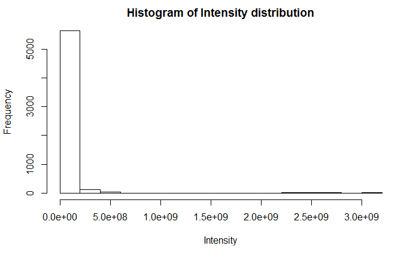

```r
hist(as.numeric(unlist(data)), main = "Histogram of Intensity distribution",  xlab = "Intensity")
```

# 3. Normalization

## 3.1 design and contrast matrix

In order to perform the normalization with the limma package we need to define the design matrix generated with model.matrix(), which identify which sample belong to which condition.

```r
#for this specific data :
exp.design <- data.frame(samples = colnames(data), condition = 1) ## first we define a matrix containing the experiment design information by associating a sample name with the condition name
exp.design$condition[1:10] = "control"
exp.design$condition[11:20] = "lessone"
exp.design$condition[21:30] = "onetofive"
exp.design$condition[31:40] = "adult"
design <- model.matrix(~0 + exp.design$condition, data = exp.design) ## model.matrix() use the experiment design to generate a matrix.
colnames(design) <- sort(unique(exp.design$condition))
row.names(design) <- exp.design$samples
as.data.frame(design)
```

|  | adult | control | lessone | onetofive |
| --- | --- | --- | --- | --- |
| Sample.1 | 0 | 1 | 0 | 0 |
| Sample.2 | 0 | 1 | 0 | 0 |
| Sample.3 | 0 | 1 | 0 | 0 |
| Sample.4 | 0 | 1 | 0 | 0 |
| Sample.5 | 0 | 1 | 0 | 0 |
| Sample.6 | 0 | 1 | 0 | 0 |
| Sample.7 | 0 | 1 | 0 | 0 |
| Sample.8 | 0 | 1 | 0 | 0 |
| Sample.9 | 0 | 1 | 0 | 0 |
| Sample.10 | 0 | 1 | 0 | 0 |

[output cut: 30 more lines]

We also need to create a contrast matrix generated with the limma function makeContrast(). This matrix allows to define the comparisons between the differents conditions to perform.

```r
contrast <- makeContrasts(adult-control, lessone-control, onetofive-control, levels=design)
as.data.frame(contrast)
```

|  | adult - control | lessone - control | onetofive - control |
| --- | --- | --- | --- |
| adult | 1 | 0 | 0 |
| control | -1 | -1 | -1 |
| lessone | 0 | 1 | 0 |
| onetofive | 0 | 0 | 1 |

## 3.2 applying limma

Now, we can normalise the dataset using the following commands. The calcNormFactors(), calculates the normalization factors to scale the library sizes.

The limma package (since version 3.16.0) offers the voom function that will normalise read counts and apply a linear model to the normalised data before computing moderated t-statistics of differential expression.

The returned data object consists of a few attributes, which you can check using names(y), one of which is the normalised expression (y$E) values in log2 scale.

```r
library(limma)
library(edgeR)
dge <- DGEList(data)
dge <- calcNormFactors(dge)
y <- voom(dge, design)
norm.data <- y$E
as.data.frame(norm.data)
```

|  | Sample.1 | Sample.2 | Sample.3 | Sample.4 | Sample.5 | Sample.6 | Sample.7 | Sample.8 | Sample.9 | Sample.10 | Sample.11 | Sample.12 | Sample.13 | Sample.14 | Sample.15 | Sample.16 | Sample.17 | Sample.18 | Sample.19 | Sample.20 | Sample.21 | Sample.22 | Sample.23 | Sample.24 | Sample.25 | Sample.26 | Sample.27 | Sample.28 | Sample.29 | … |
| --- | --- | --- | --- | --- | --- | --- | --- | --- | --- | --- | --- | --- | --- | --- | --- | --- | --- | --- | --- | --- | --- | --- | --- | --- | --- | --- | --- | --- | --- | --- |
| sp\|A0M8Q6\|LAC7_HUMAN | 4.60446222 | 0.5055914 | 3.492179 | 3.65027387 | 5.143672 | 0.6212977 | 10.4920947 | 1.2040810 | 0.5484876 | 3.1836461 | 3.34318403 | 2.9583776 | 2.68572012 | 3.57816245 | 1.7138879 | 9.19507451 | 1.4410603 | 1.96023970 | 9.8511836 | 4.9281048 | 8.5740584 | 9.9618777 | 9.0533306 | 9.1406581 | 9.45658034 | 4.5003431 | 9.3507680 | 4.7673698 | 9.9728355 | … |
| sp\|B9A064\|IGLL5_HUMAN | 10.48150326 | 10.2261201 | 10.597497 | 10.65453915 | 11.655665 | 11.1746138 | 10.8528529 | 10.6569613 | 10.7281657 | 10.6740158 | 8.84363885 | 9.7703664 | 8.39268015 | 9.86374219 | 9.9600926 | 9.29404399 | 9.6360274 | 9.34447584 | 9.7911274 | 9.6907452 | 10.6087988 | 10.6845414 | 10.1576821 | 10.4476131 | 10.58904421 | 11.1774620 | 10.7472601 | 10.7976451 | 10.7420080 | … |
| sp\|O14791\|APOL1_HUMAN | 11.09223541 | 10.0698636 | 10.432834 | 10.67362161 | 9.909948 | 5.3013943 | 11.2342625 | 5.3401031 | 4.9284414 | 5.8468598 | 10.66262798 | 7.4943440 | 7.34045089 | 6.67863049 | 6.8309142 | 10.07702834 | 10.6640996 | 10.57905311 | 6.2041713 | 7.2160621 | 7.4385088 | 7.0100619 | 7.2069653 | 7.2920264 | 7.28156285 | 7.4330379 | 6.8411972 | 7.2744168 | 6.5302230 | … |
| sp\|O43866\|CD5L_HUMAN | 4.15332466 | 6.5805433 | 4.724453 | 5.41691606 | 4.577682 | 5.5970576 | 3.9748824 | 5.2312486 | 4.3880751 | 4.7914590 | 8.17339097 | 7.5262134 | 8.37894112 | 7.46336447 | 7.5135415 | 8.12974501 | 7.5146784 | 7.08370538 | 7.4197906 | 7.6846516 | 7.9472563 | 8.9756104 | 6.4971436 | 6.7959123 | 8.01919686 | 7.1698038 | 7.2074958 | 8.0952955 | 7.8846949 | … |
| sp\|O75636\|FCN3_HUMAN | 5.80246769 | 5.9396146 | 5.888938 | 6.02983471 | 6.245160 | 6.1302407 | 5.2224654 | 4.8878823 | 6.0750699 | 6.3253285 | 6.82990348 | 6.5799225 | 6.70142869 | 6.33451648 | 6.3621389 | 6.25985223 | 6.5218798 | 6.42756289 | 5.4832813 | 6.1406320 | 6.0589428 | 6.1027626 | 6.0198083 | 6.2463778 | 5.98495615 | 5.4735525 | 6.2541870 | 6.0393238 | 6.0510946 | … |
| sp\|O75882\|ATRN_HUMAN | 5.26850288 | 4.5871772 | 4.472944 | 5.28297710 | 5.507024 | 5.2257447 | 4.9865733 | 5.1205447 | 4.7671745 | 5.1432460 | 5.25407458 | 5.1479343 | 5.27216966 | 4.96419550 | 5.2802401 | 5.51244813 | 4.8921751 | 5.39786809 | 4.8885501 | 4.9594671 | 5.1931204 | 5.3784994 | 5.1146962 | 6.0081456 | 5.13267649 | 4.9661618 | 4.9092554 | 5.1310641 | 5.2079141 | … |
| sp\|O95445\|APOM_HUMAN | 7.79728384 | 8.4396485 | 7.830151 | 7.65507101 | 7.831950 | 8.2569016 | 8.4237376 | 8.4015746 | 8.5641416 | 8.8303318 | 9.03590945 | 8.5171522 | 9.34596418 | 8.81097615 | 9.0712010 | 8.90068568 | 8.4611037 | 9.00183783 | 8.2284225 | 8.2646648 | 8.3150356 | 8.3438276 | 8.4821243 | 7.9557947 | 8.53115330 | 8.3289127 | 8.2423565 | 7.5707156 | 8.5920608 | … |
| sp\|P00450\|CERU_HUMAN | 11.33273816 | 11.4564145 | 12.048147 | 12.93163803 | 11.697634 | 11.7055416 | 12.2683602 | 12.2934674 | 11.9961248 | 11.2634224 | 12.80966248 | 13.2752610 | 12.93949587 | 12.80296251 | 12.7012863 | 12.83848400 | 12.6989103 | 12.74025364 | 12.7199037 | 13.1898344 | 12.9242170 | 12.9151604 | 13.0798430 | 12.9309429 | 12.77942965 | 12.3111700 | 12.9462767 | 12.9650753 | 12.8038121 | … |
| sp\|P00734\|THRB_HUMAN | 10.16621722 | 10.7025417 | 10.808935 | 10.82130152 | 10.214388 | 10.7931321 | 10.2360499 | 11.0369636 | 11.0788536 | 11.0157718 | 11.68873563 | 11.2355350 | 11.55019532 | 11.19015413 | 11.4607675 | 11.33593558 | 10.9946154 | 11.30631931 | 11.4746278 | 11.2861266 | 11.0123384 | 11.0768353 | 11.2603593 | 11.3899527 | 11.19847768 | 10.7463741 | 11.2064351 | 11.3341980 | 11.1223716 | … |
| sp\|P00736\|C1R_HUMAN | 7.28410826 | 6.6676879 | 6.902765 | 7.57700778 | 7.347838 | 7.5868280 | 7.3257477 | 7.4560111 | 7.4484713 | 6.9237613 | 6.41731669 | 7.0796733 | 7.10943863 | 6.95712003 | 7.1788597 | 7.13489120 | 7.3928929 | 7.12455493 | 7.4110428 | 7.0449334 | 7.0966102 | 6.5683242 | 7.1341879 | 7.1073455 | 7.27660526 | 6.9061620 | 6.7605631 | 7.0915208 | 6.6459851 | … |

[output cut: 136 more lines]

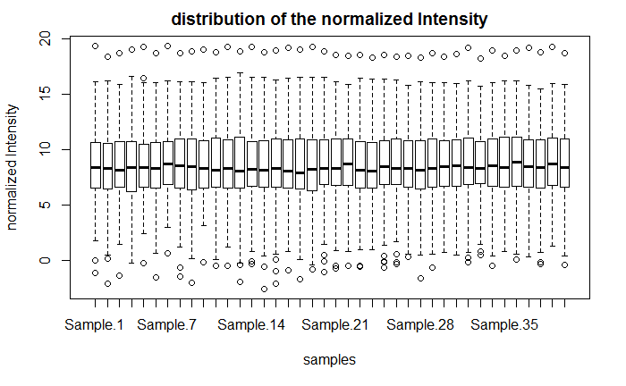

```r
boxplot(norm.data, ylab="normalized Intensity", xlab="samples", main = "distribution of the normalized Intensity")
```

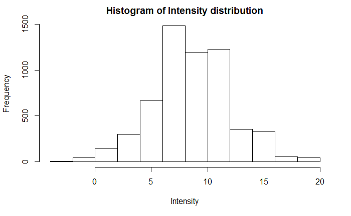

```r
hist(norm.data, main = "Histogram of Intensity distribution",  xlab = "Intensity")
```

# 4. Differential expression annalysis

## 4.1 fitting the model

To fit the model, use the lmFit() function, which takes in the normalised data object and the design matrix:

```r
fit <- lmFit(y, design)
```

Refit the model using the comparisons defined:

```r
fit2 <- contrasts.fit(fit, contrast)
fit2 <- eBayes(fit2)
```

## 4.2 Extracting the results

The topTable function summarises the output from limma in a table format.

```r
adult.vs.c <- topTable(fit2, coef = "adult - control", n = nrow(fit2))
lessone.vs.control <- topTable(fit2, coef = "lessone - control", n = nrow(fit2))
onetofive.vs.control <- topTable(fit2, coef = "onetofive - control", n = nrow(fit2))
adult.vs.c ; lessone.vs.control ; onetofive.vs.control
```

|  | logFC | AveExpr | t | P.Value | adj.P.Val | B |
| --- | --- | --- | --- | --- | --- | --- |
| sp\|P01876\|IGHA1_HUMAN | 5.747508478 | 10.1062371 | 20.34829437 | 2.129518e-22 | 3.109096e-20 | 40.98827654 |
| sp\|P69892\|HBG2_HUMAN | -8.481437888 | 3.7841261 | -19.47758305 | 1.012502e-21 | 7.391262e-20 | 39.10231263 |
| sp\|P02452\|CO1A1_HUMAN | -3.205380071 | 3.5335676 | -15.40220494 | 3.453307e-18 | 1.260457e-16 | 31.15654342 |
| sp\|P02790\|HEMO_HUMAN | 1.093709908 | 13.4066860 | 15.44587795 | 3.139073e-18 | 1.260457e-16 | 31.14506477 |
| sp\|P01877\|IGHA2_HUMAN | 4.686044933 | 5.8729258 | 12.58756850 | 2.511949e-15 | 7.093740e-14 | 24.82728568 |
| sp\|P69891\|HBG1_HUMAN | -6.682334373 | 3.6099151 | -12.52821317 | 2.915236e-15 | 7.093740e-14 | 24.68419735 |
| sp\|P01591\|IGJ_HUMAN | 3.585828544 | 6.9269399 | 11.91551196 | 1.390751e-14 | 2.900710e-13 | 23.10272037 |
| sp\|P01023\|A2MG_HUMAN | -1.272031678 | 15.9110465 | -10.80253882 | 2.684207e-13 | 4.898678e-12 | 19.55196332 |
| sp\|P01871\|IGHM_HUMAN | 3.060971254 | 10.2948746 | 10.25358715 | 1.226125e-12 | 1.903603e-11 | 18.33539435 |
| sp\|P02649\|APOE_HUMAN | -1.576114808 | 10.5050975 | -10.23167362 | 1.303838e-12 | 1.903603e-11 | 18.18234514 |

[output cut: 136 more lines]

|  | logFC | AveExpr | t | P.Value | adj.P.Val | B |
| --- | --- | --- | --- | --- | --- | --- |
| sp\|P02790\|HEMO_HUMAN | 1.349569219 | 13.4066860 | 19.091116560 | 2.060260e-21 | 3.007979e-19 | 38.73010841 |
| sp\|P69892\|HBG2_HUMAN | -7.563190837 | 3.7841261 | -18.287852385 | 9.369284e-21 | 6.839577e-19 | 36.10269205 |
| sp\|P05546\|HEP2_HUMAN | 1.368787655 | 9.3950435 | 12.342520473 | 4.657877e-15 | 1.879304e-13 | 24.20402290 |
| sp\|P69891\|HBG1_HUMAN | -6.611931871 | 3.6099151 | -12.303032911 | 5.148779e-15 | 1.879304e-13 | 23.84331905 |
| sp\|P01834\|IGKC_HUMAN | -1.531054999 | 14.7113924 | -11.250944893 | 7.990024e-14 | 2.333087e-12 | 21.15818872 |
| sp\|P01859\|IGHG2_HUMAN | -1.656968812 | 10.2892057 | -10.461622528 | 6.863065e-13 | 1.670013e-11 | 19.18602523 |
| sp\|P01876\|IGHA1_HUMAN | 3.113738664 | 10.1062371 | 10.272802713 | 1.161862e-12 | 2.423312e-11 | 18.74610775 |
| sp\|P80748\|LV302_HUMAN | -1.866336989 | 8.7965327 | -9.274769695 | 2.027072e-11 | 3.004632e-10 | 15.87977528 |
| sp\|P04003\|C4BPA_HUMAN | 1.699031830 | 10.2463083 | 9.269604820 | 2.057967e-11 | 3.004632e-10 | 15.79416371 |
| sp\|P01860\|IGHG3_HUMAN | -1.332960950 | 12.7441424 | -9.279422153 | 1.999645e-11 | 3.004632e-10 | 15.65395680 |

[output cut: 136 more lines]

|  | logFC | AveExpr | t | P.Value | adj.P.Val | B |
| --- | --- | --- | --- | --- | --- | --- |
| sp\|P69892\|HBG2_HUMAN | -8.270620473 | 3.7841261 | -19.440356052 | 1.083669e-21 | 1.582156e-19 | 39.31939949 |
| sp\|P02790\|HEMO_HUMAN | 1.239978606 | 13.4066860 | 17.607551277 | 3.524173e-20 | 2.572646e-18 | 35.49962507 |
| sp\|P01876\|IGHA1_HUMAN | 4.088498851 | 10.1062371 | 14.094952221 | 6.593323e-17 | 3.208750e-15 | 28.15856929 |
| sp\|P69891\|HBG1_HUMAN | -6.317755830 | 3.6099151 | -12.233234589 | 6.149356e-15 | 2.244515e-13 | 23.88855838 |
| sp\|P04003\|C4BPA_HUMAN | 1.906333089 | 10.2463083 | 10.569159411 | 5.095719e-13 | 1.487950e-11 | 18.97507655 |
| sp\|P05546\|HEP2_HUMAN | 1.144448390 | 9.3950435 | 10.364160651 | 9.000783e-13 | 2.190190e-11 | 18.46205178 |
| sp\|Q96IY4\|CBPB2_HUMAN | 1.116710622 | 4.8576245 | 9.336386833 | 1.692815e-11 | 3.089387e-10 | 15.95758689 |
| sp\|P02771\|FETA_HUMAN | -3.232611230 | 7.1101511 | -9.413128443 | 1.353412e-11 | 2.822831e-10 | 15.89149189 |
| sp\|P01591\|IGJ_HUMAN | 2.804932608 | 6.9269399 | 9.171654952 | 2.743444e-11 | 4.347628e-10 | 15.35331815 |
| sp\|P01871\|IGHM_HUMAN | 2.743325685 | 10.2948746 | 9.141986676 | 2.993758e-11 | 4.347628e-10 | 14.89057201 |

[output cut: 136 more lines]

We keep only the values of interest like the p value, the adjusted p value and the fold change to create the volcano plot. The results for the different pairwise comparison are stored in a list of dataframe.

```r
adult.vs.c$protein <- row.names(adult.vs.c)
row.names(adult.vs.c) <- NULL
adult.vs.c <- adult.vs.c[, c(7, 4, 5, 1)]
lessone.vs.control$protein <- row.names(lessone.vs.control)
row.names(lessone.vs.control) <- NULL
lessone.vs.control <- lessone.vs.control[, c(7, 4, 5, 1)]
onetofive.vs.control$protein <- row.names(onetofive.vs.control)
row.names(onetofive.vs.control) <- NULL
onetofive.vs.control <- onetofive.vs.control[, c(7, 4, 5, 1)]
Results <- list(adult.vs.c, lessone.vs.control, onetofive.vs.control)
```

## 4.2 Differentially expressed proteins

```r
thresh_fc <- 0.5
thresh_p <- 0.05
deProt <- Results
for(i in 1:length(Results)){
    fc = as.data.frame(deProt[[i]])[,4]
    p = as.data.frame(deProt[[i]])[,3]
    dt <-as.data.frame(deProt[[i]])
    deProt[[i]] <- dt[which(p<=thresh_p & abs(fc)>=thresh_fc),]
    print(as.data.frame(deProt[[i]]))
  }
```

|  | protein | P.Value | adj.P.Val | logFC |
| --- | --- | --- | --- | --- |
| 1 | sp\|P01876\|IGHA1_HUMAN | 2.129518e-22 | 3.109096e-20 | 5.7475085 |
| 2 | sp\|P69892\|HBG2_HUMAN | 1.012502e-21 | 7.391262e-20 | -8.4814379 |
| 3 | sp\|P02452\|CO1A1_HUMAN | 3.453307e-18 | 1.260457e-16 | -3.2053801 |
| 4 | sp\|P02790\|HEMO_HUMAN | 3.139073e-18 | 1.260457e-16 | 1.0937099 |
| 5 | sp\|P01877\|IGHA2_HUMAN | 2.511949e-15 | 7.093740e-14 | 4.6860449 |
| 6 | sp\|P69891\|HBG1_HUMAN | 2.915236e-15 | 7.093740e-14 | -6.6823344 |
| 7 | sp\|P01591\|IGJ_HUMAN | 1.390751e-14 | 2.900710e-13 | 3.5858285 |
| 8 | sp\|P01023\|A2MG_HUMAN | 2.684207e-13 | 4.898678e-12 | -1.2720317 |
| 9 | sp\|P01871\|IGHM_HUMAN | 1.226125e-12 | 1.903603e-11 | 3.0609713 |
| 10 | sp\|P02649\|APOE_HUMAN | 1.303838e-12 | 1.903603e-11 | -1.5761148 |

[output cut: 46 more lines]

|  | protein | P.Value | adj.P.Val | logFC |
| --- | --- | --- | --- | --- |
| 1 | sp\|P02790\|HEMO_HUMAN | 2.060260e-21 | 3.007979e-19 | 1.3495692 |
| 2 | sp\|P69892\|HBG2_HUMAN | 9.369284e-21 | 6.839577e-19 | -7.5631908 |
| 3 | sp\|P05546\|HEP2_HUMAN | 4.657877e-15 | 1.879304e-13 | 1.3687877 |
| 4 | sp\|P69891\|HBG1_HUMAN | 5.148779e-15 | 1.879304e-13 | -6.6119319 |
| 5 | sp\|P01834\|IGKC_HUMAN | 7.990024e-14 | 2.333087e-12 | -1.5310550 |
| 6 | sp\|P01859\|IGHG2_HUMAN | 6.863065e-13 | 1.670013e-11 | -1.6569688 |
| 7 | sp\|P01876\|IGHA1_HUMAN | 1.161862e-12 | 2.423312e-11 | 3.1137387 |
| 8 | sp\|P80748\|LV302_HUMAN | 2.027072e-11 | 3.004632e-10 | -1.8663370 |
| 9 | sp\|P04003\|C4BPA_HUMAN | 2.057967e-11 | 3.004632e-10 | 1.6990318 |
| 10 | sp\|P01860\|IGHG3_HUMAN | 1.999645e-11 | 3.004632e-10 | -1.3329610 |

[output cut: 69 more lines]

|  | protein | P.Value | adj.P.Val | logFC |
| --- | --- | --- | --- | --- |
| 1 | sp\|P69892\|HBG2_HUMAN | 1.083669e-21 | 1.582156e-19 | -8.2706205 |
| 2 | sp\|P02790\|HEMO_HUMAN | 3.524173e-20 | 2.572646e-18 | 1.2399786 |
| 3 | sp\|P01876\|IGHA1_HUMAN | 6.593323e-17 | 3.208750e-15 | 4.0884989 |
| 4 | sp\|P69891\|HBG1_HUMAN | 6.149356e-15 | 2.244515e-13 | -6.3177558 |
| 5 | sp\|P04003\|C4BPA_HUMAN | 5.095719e-13 | 1.487950e-11 | 1.9063331 |
| 6 | sp\|P05546\|HEP2_HUMAN | 9.000783e-13 | 2.190190e-11 | 1.1444484 |
| 7 | sp\|Q96IY4\|CBPB2_HUMAN | 1.692815e-11 | 3.089387e-10 | 1.1167106 |
| 8 | sp\|P02771\|FETA_HUMAN | 1.353412e-11 | 2.822831e-10 | -3.2326112 |
| 9 | sp\|P01591\|IGJ_HUMAN | 2.743444e-11 | 4.347628e-10 | 2.8049326 |
| 10 | sp\|P01871\|IGHM_HUMAN | 2.993758e-11 | 4.347628e-10 | 2.7433257 |

[output cut: 60 more lines]